# Ranking models for UK All-Weather Flat handicaps: the exploded conditional logit and the place market

Paper 2b in a series on UK All-Weather racing outcomes

Author

Patrick Gillen

Published

July 3, 2026

Abstract

Paper 2a established a win-prediction model on UK All-Weather Flat handicaps using an extended feature set and race-level interactions. This paper holds that feature set fixed and asks three questions in turn. First (Q1), refitted under a ranking objective — the exploded conditional logit, equivalent to maximising the Plackett–Luce likelihood over the top-3 finishing order — how well does the model predict that order? We measure it with P1_rank and a top-3 Brier score, using market-implied ordering probabilities derived from starting prices via Harville’s sequential-conditioning formula as the comparison: the model predicts the finishing order with clear skill above chance, and the market scores higher on both metrics. Second (Q2), because the model is now fitted on richer depth-3 ranking supervision, how does it pick *winners* compared with 2a’s win-fitted model? On the depth-1 win backtest it returns -17.4% against 2a’s -25.4%; both models remain a net loss against the market. Third (Q3), turned into a realistic one-bet-per-race strategy — backing the single highest-probability qualifier, priced at real starting prices — place returns -9.8% and each-way -7.7%, roughly half the drag of backing every qualifier and, for place, about half the ~16% structural SP margin. As Q1 predicts, the market’s place probabilities remain the more accurate, and on the win market single-bet makes no difference.

# 1 Introduction

Paper 2a fixed the prediction objective as the *win* and asked how far an enriched feature set could narrow the gap to the betting market on UK All-Weather Flat handicaps. This paper holds that feature set fixed and asks three questions in order.

**Q1 — ranking performance.** Refitting the same features from scratch under a ranking objective — the exploded conditional logit, which maximises the Plackett–Luce likelihood over the top-3 finishing order — how well does the model predict that order? We re-estimate the whole model on the ranking objective, noting where its feature selection departs from paper 2a’s (the draw×course block, re-searched here, retains three courses where 2a kept two; Section 3), and measure performance with two ranking metrics, P1_rank and a top-3 Brier score, against the market’s ordering probabilities derived from starting prices via Harville. The model predicts the finishing order with clear skill above chance, and the market scores higher on both metrics.

**Q2 — win performance as a byproduct.** Because the model is now fitted on richer depth-3 ranking supervision rather than depth-1 win supervision, how does it pick *winners* compared with 2a’s win-fitted model? On the depth-1 win backtest the ranking-fitted model returns a higher (less negative) ROI, by a margin a paired bootstrap places above zero though close to it; both models remain a net loss against the market.

**Q3 — betting value.** Does the model’s place-probability accuracy translate into betting value under a realistic strategy — one bet per race, the single highest-probability qualifier, priced at real starting prices? On the place and each-way markets it returns better than backing every qualifier, though still short of a profit; on the win market it makes no difference. As Q1 predicts, the market’s place probabilities are the more accurate.

Section 2 points to paper 2a for the shared data and feature set and constructs the market’s ordering probabilities from starting prices; Section 3 fits the ranking model and re-searches the course×draw block; Section 4 answers Q1, then Q2, then Q3; and Section 5 draws the threads together.

# 2 Data and scope

The data, the race-selection rules, the train/test split and the feature set are identical to paper 2a; we refer the reader there (paper 2a, §2) rather than repeat them. The one genuinely new ingredient this paper needs is a set of market-implied ordering probabilities, constructed below.

## 2.1 Market-implied ordering probabilities: discounted Harville

The starting-price win probability used in papers 1 and 2a — over-round adjusted — cannot be directly applied to a top-3 ranking objective. We require market-implied *ordering* probabilities — the probability of each horse finishing first, second, or third — for each horse.

We derive these from win starting prices using the discounted Harville formula (Lo and Bacon-Shone 1994, 2008). Pure Harville (Harville 1973) rests on a single assumption: once the winner is removed, the remaining horses “re-race” with win probabilities proportional to their original ones — the field’s relative strengths are unchanged by the outcome. Under that assumption the probability that horse $j$ finishes second given horse $i$ won is $p_j / (1 - p_i)$, where $p_k$ denotes win probability; the probability of a specific top-2 order $(i, j)$ is $p_i\, p_j / (1 - p_i)$, and the same conditioning extends to deeper rankings.

We use discounted Harville to build the market’s probabilities for both metrics — the P1_rank order probability and the Brier_place place probability. The reason to discount rather than use pure Harville is a known bias: pure Harville overstates the place chances of favourites and understates those of longer-priced horses, the favourite–longshot bias operating in the place dimension. That bias sits in the marginal place probabilities and carries through into the joint top-3 order probabilities, so pure Harville would be a biased comparison for both metrics. The discounted form of Lo & Bacon-Shone corrects it by replacing each win probability $p_k$ with $p_k^{\alpha}$ ($\alpha < 1$) inside the conditional steps before renormalising, with a smaller $\alpha$ at deeper positions; we use $\alpha = 0.80$ for second place and $\alpha = 0.65$ for third, Lo & Bacon-Shone’s recommended values for starting-price inputs.

# 3 The exploded conditional logit and the course×draw search

The win model of paper 2a uses only one bit of each race’s result: who won. The finishing order carries more. The **exploded conditional logit** (Henery 1981) uses it by treating the observed order as a sequence of conditional win problems — the winner is chosen from the full field, the runner-up from the field minus the winner, the third from the field minus the first two — and pooling those sub-races into a single conditional-logit fit, which is exactly maximising the Plackett–Luce likelihood. We truncate at depth $k = 3$: only the top-3 order is modelled, the tail of the field being largely noise (Henery 1981). The algebra and the Plackett–Luce equivalence are derived in Section 6.

The specification is the same 17 terms that survived paper 2a’s feature reduction — the same zero-plus-slope position encoding, the same imputed `or_relative`/`or_missing` — so any difference at this stage is the explosion, not the features. The draw×course block is then searched **independently** of paper 2a (below); we do not assume 2a’s surviving courses carry over.

## 3.1 From win to ranking: the exploded construction

For each race we form $k = 3$ sub-races: choice set $s$ is the horse that finished $s$th together with every horse not yet ranked — all finishers placed $s$-or-worse plus any non-finishers, which never get ranked and so stay in the pool at every depth. The depth-1 sub-race is therefore exactly the win model’s choice set (the full field, winner = 1st), which makes the two models comparable at depth 1; each sub-race has exactly one winner.

Two race filters apply. Races with any missing value in the modelling columns are dropped (the same rule as the win model), and races whose top-3 positions are not each recorded exactly once — a dead-heat for 2nd or 3rd, or a gap — cannot be unambiguously exploded and are dropped too. Finishing position is the official placing, taking the amended placing where a result was later revised.

Table 1: Exploded training data (carrying the draw-course columns): 5,022 valid races become 15,066 choice sets (3 per race) over 122,844 runner-rows.

| Sub-race | Runner-rows |
| --- | --- |
| depth 1 (full field) | 45,970 |
| depth 2 (field − 1st) | 40,948 |
| depth 3 (field − 1st,2nd) | 35,926 |

The runner-row count falls by one per race at each successive depth: the same races contribute to all three sub-races, but each deeper sub-race drops the horses already placed above it (depth 2 removes the winner, depth 3 the first two), so the choice set shrinks by one runner each time.

## 3.2 Fitting the ranking model

We carry paper 2a’s reduced 17-feature specification — the feature-by-feature selection was settled there — and re-estimate it under the ranking objective, entering the four-course draw×course block (Kempton, Lingfield, Southwell, Wolverhampton) from the start. The draw block is then reduced by the same per-term $p < 0.05$ rule paper 2a applies to its win model, run fresh on this fit: the least significant non-significant course slope is dropped, the model refit, and the step repeated until every surviving slope clears the threshold.

Re-estimating under the explosion moves the coefficients in two ways: the estimates shrink in magnitude, and the z-values mostly rise. Both are shown against paper 2a’s win fit on the identical specification.

Table 2: Paper 2a reduced win model (depth-1) vs the exploded fit on the same 17 terms (depth-3 Plackett–Luce). Estimates and z-values side by side.

| Block | Term | Win est. | Win z | Exploded est. | Exploded z |
| --- | --- | --- | --- | --- | --- |
| 1. Position (zero-plus-slope) | pos_lag1_zero | -0.8239 | -15.69 | -0.7361 | -23.59 |
| 1. Position (zero-plus-slope) | pos_lag1_nonzero | -0.1494 | -8.19 | -0.1179 | -10.99 |
| 1. Position (zero-plus-slope) | pos_lag2_zero | -0.3258 | -6.02 | -0.3148 | -9.86 |
| 1. Position (zero-plus-slope) | pos_lag2_nonzero | -0.0495 | -2.61 | -0.0335 | -3.02 |
| 2. Form / history | daysLTO (log) | -0.1277 | -7.13 | -0.1525 | -14.71 |
| 2. Form / history | trainerSR | 3.3172 | 7.93 | 3.0582 | 12.26 |
| 2. Form / history | sireSR | 1.8271 | 4.33 | 1.0975 | 4.29 |
| 3. Horse characteristics | age_diff | -0.0915 | -6.54 | -0.0579 | -7.36 |
| 3. Horse characteristics | entire | 0.4411 | 7.69 | 0.3374 | 9.85 |
| 3. Horse characteristics | gelding | 0.2433 | 5.37 | 0.2205 | 8.47 |
| 3. Horse characteristics | cheekpieces | -0.2690 | -4.38 | -0.1406 | -4.16 |
| 4. New features (introduced in paper 2a) | jockeySR | 4.0923 | 8.48 | 2.7528 | 9.72 |
| 4. New features (introduced in paper 2a) | rel_weight | -0.0309 | -6.60 | -0.0095 | -3.55 |
| 4. New features (introduced in paper 2a) | or_relative | 0.0783 | 18.36 | 0.0455 | 19.52 |
| 4. New features (introduced in paper 2a) | or_missing | -0.3845 | -4.46 | -0.4646 | -9.27 |
| 4. New features (introduced in paper 2a) | trainer_aw_premium | 1.7298 | 3.91 | 1.3906 | 5.33 |
| 4. New features (introduced in paper 2a) | has_wins | 0.1209 | 2.16 | 0.0939 | 2.93 |

The estimates shrink — most coefficients are smaller in magnitude under the explosion, because the win model loads each feature with all of its power to separate the *winner* from the field, whereas the exploded model must make the same coefficient explain the 1-vs-rest, 2-vs-rest and 3-vs-rest contrasts at once. The z-values mostly move the other way, rising, as depth-3 explosion roughly triples the number of choice problems the same races supply; the form and position terms, which order the whole field rather than just crown the winner, change the most.

Table 3: Per-term reduction of the exploded draw×course block. Each step drops the least significant non-significant course slope and refits; the 1-df likelihood-ratio drop-test is reported alongside.

| Step | Dropped | p | From → to | LR stat | df | LR p |
| --- | --- | --- | --- | --- | --- | --- |
| 1 | lingfield | 0.91 | 4-course → 3-course | 0.013 | 1 | 0.91 |

Only **Lingfield** drops ($p =$ 0.91; the 1-df LR drop-test agrees, $p =$ 0.91). The surviving block is **Kempton, Southwell and Wolverhampton** — three courses, where paper 2a’s win model retained only **Kempton and Southwell**. The difference is Wolverhampton. On the exploded fit Wolverhampton’s draw slope is -0.182 ($p =$ 0.0003); in paper 2a’s win model it was -0.160 ($p \approx 0.066$) — the **same sign and similar magnitude, estimated far more sharply**. The reading is the narrow one: the ranking objective estimates the same draw effect paper 2a saw, sharply enough to retain it, rather than uncovering a new effect the win model missed. The negative slope (an advantage to lower draws) is the direction 2a already found and is directionally consistent with a tight, left-handed All-Weather track; it is a single distance-pooled slope, so it is an average direction across trips, not a trip-specific law.

The final paper-2b model is the 17-term exploded fit plus the three retained course-draw slopes — 20 coefficients in all.

Table 4: Draw×course coefficients in the full four-course block (the selection-stage exploded fit). Kempton, Southwell and Wolverhampton are individually significant and retained; Lingfield is not and is dropped, leaving the three-course final model.

| Course | Estimate | Std. error | z | p-value | Retained |
| --- | --- | --- | --- | --- | --- |
| Kempton | 0.1368 | 0.0510 | 2.68 | 0.007280 | yes |
| Lingfield | -0.0061 | 0.0541 | -0.11 | 0.910000 | dropped |
| Southwell | 0.1683 | 0.0698 | 2.41 | 0.015900 | yes |
| Wolverhampton | -0.1816 | 0.0505 | -3.60 | 0.000323 | yes |

# 4 Evaluation on ranking metrics

This paper asks three questions, in order. **Q1** is the ranking question the paper is built around: how well does the exploded model predict the top-3 finishing order, measured against the market? **Q2** is a byproduct: because the model is fitted on richer (depth-3) ranking supervision rather than depth-1 win supervision, how does it pick *winners* compared with paper 2a’s win-fitted model? **Q3** is the applied question: turned into bets, does that place-probability accuracy translate into betting value? The three are answered separately, each against its own comparison.

## 4.1 Ranking metrics

We evaluate ranking on two metrics, both computed out-of-sample on the held-out test races.

**P1_rank** (ranking discrimination): the geometric mean, over test races, of the Plackett–Luce probability assigned to the observed top-3 finishing order. Computed as the exponentiated mean log-likelihood per race to avoid numerical underflow:
$$\text{P1}_{\text{rank}}
= \exp\!\left( \frac{1}{n} \sum_{i} \log P(j_1^i, j_2^i, j_3^i) \right),$$
where $P(j_1, j_2, j_3)$ is the depth-3 Plackett–Luce probability of the observed order under the model or market. Higher is better. This is the ranking analogue of Owen’s P1. Working in log-space — summing log-probabilities rather than multiplying probabilities directly — avoids floating-point underflow when the product of many small probabilities would otherwise round to zero; the geometric mean is recovered by exponentiating at the end.

**Brier_place** (place calibration): the mean squared error between the predicted place probability and the binary place outcome (top-3 or not), averaged over all runner-race observations in the test set:
$$\text{Brier}_{\text{place}}
= \frac{1}{N} \sum_{i,j} \left( \text{place}_{ij} - p^{\text{place}}_{ij} \right)^2,$$
where $\text{place}_{ij} = 1$ if horse $j$ finished in the top 3 in race $i$, and $p^{\text{place}}_{ij}$ is the model- or market-implied probability of a top-3 finish. Lower is better; a proper scoring rule, analogous to Owen’s P2.

The market’s probabilities for both metrics use discounted Harville ($\alpha = 0.80$ for the second-place conditional, $0.65$ for the third; Section 2): the place probabilities for Brier_place and the depth-3 order probability for P1_rank are both built from the same discounted starting-price win probabilities. For each metric, the model’s fitted win probabilities are substituted into the same Plackett–Luce formula (with $\alpha = 1$, no discounting) to produce its predicted ordering and place probabilities.

## 4.2 Q1 — Ranking performance against the market

The model is scored on 2,183 test races[^1] against the market’s discounted-Harville ordering probabilities.

Table 5: Ranking metrics on the 2,183 scorable test races: exploded model vs the market’s discounted-Harville probabilities.

| Metric | Model | Market | Better | Winner |
| --- | --- | --- | --- | --- |
| P1_rank | 0.00402 | 0.005427 | higher | market |
| Brier_place | 0.20130 | 0.187500 | lower | market |

The model predicts the top-3 order with clear skill above chance. Random guessing scores about 0.003 on P1_rank — roughly the reciprocal of the number of possible top-3 orderings in a typical field — and about 0.23 on Brier_place, the score from predicting every horse’s place chance at the base rate. The model scores 0.00402 on P1_rank (higher is better) and 0.201 on Brier_place (lower is better), well inside the skilled range on both. Measured against the market’s discounted-Harville probabilities, the market scores higher on each — 0.00543 on P1_rank and 0.188 on Brier_place. The model has genuine ranking skill; the market, here as in papers 1 and 2a, sets the higher mark, consistent with the starting price aggregating information the pre-race feature set does not contain.

## 4.3 Q2 — Win performance as a byproduct

The same fully-specified three-course exploded model can be judged on the *win* objective, by reading off its depth-1 win probabilities and running paper 2a’s exact betting backtest. The question is not whether it beats the market — neither model does — but whether ranking supervision makes it a better or worse winner-picker than paper 2a’s win-fitted model.

Table 6: Exploded (ranking-fitted) model on the depth-1 win backtest, AW test races at Owen’s exact thresholds.

| Prob threshold | Ratio threshold | Bets | Wins | Gross return | Profit | ROI |
| --- | --- | --- | --- | --- | --- | --- |
| 0.15 | 1.3 | 1426 | 160 | 1177.50 | -248.50 | -17.4% |

The ranking-fitted model returns a naive win ROI of **-17.4%**, against paper 2a’s win-fitted headline of **-25.4%** — both struck on the identical 2,193-race test set. Since both models are evaluated on the same test races, we compare them race by race — computing the difference in per-race profit between the two models — and bootstrap the mean of those differences (B = 2000, seed 42) to get a confidence interval on the average gain: a point difference of **+8.0 pp** in the ranking model’s favour, with a 90% interval of **[+1.0 pp, +14.8 pp]**.

Table 7: Paired race-level ROI-difference bootstrap (2b ranking-fitted minus 2a win-fitted), restricted to the common test races.

| Contrast | ROI diff. | 90% CI | Common races |
| --- | --- | --- | --- |
| 2b ranking-fitted - 2a win-fitted | +8.0 pp | [+1.0 pp, +14.8 pp] | 2,193 |

## 4.4 Q3 — Does place-probability accuracy translate into betting value?

Q1 and Q2 read the model against the market on scoring rules. The applied question is whether that accuracy translates into betting value: priced and selected as bets, do the model’s probabilities return more than the market’s? We ask it of two bet types — a horse to finish in the top three (**place**) and the same horse staked win-and-place at standard each-way terms (**each-way**) — each priced and selected entirely from win starting prices, with no separate place or each-way market prices used or needed.

Owen’s naive rule backs every horse clearing both thresholds (win probability above 0.15 and model/market ratio above 1.3), which can mean several bets in one race. A more realistic strategy places one bet per race: among the qualifiers, back the single horse with the highest model win probability. We take this **single-bet** rule as primary and report the **multi-bet** rule (back all qualifiers) alongside for continuity with papers 1 and 2a — Owen does not specify which he used. Both are priced at the real industry-SP book (observed average over-round 16.1%), the same basis as the Q2 win backtest: the place price is derived from the raw SP-implied win probabilities via Harville, and the each-way win leg pays the raw SP win odds with the place leg at one fifth of those odds on a top-3 finish (standard terms). Both are swept over the ratio threshold $\tau$.

Table 8: Place and each-way betting at Owen’s naive thresholds (ratio > 1.3), priced on the real industry-SP book (observed average over-round 16.1%). Single-bet (one bet per race, the highest-model-win-probability qualifier) is the primary rule; multi-bet (all qualifiers) is shown for continuity with papers 1/2a. 90% CI from a race-level bootstrap (B = 2000, seed 42).

| Bet type | Bets | Single-bet ROI | 90% CI | Multi-bet ROI |
| --- | --- | --- | --- | --- |
| Place | 1,145 | -9.8% | [-15.5%, -4.1%] | -17.3% |
| Each-way | 1,145 | -7.7% | [-15.5%, -0.1%] | -26.3% |

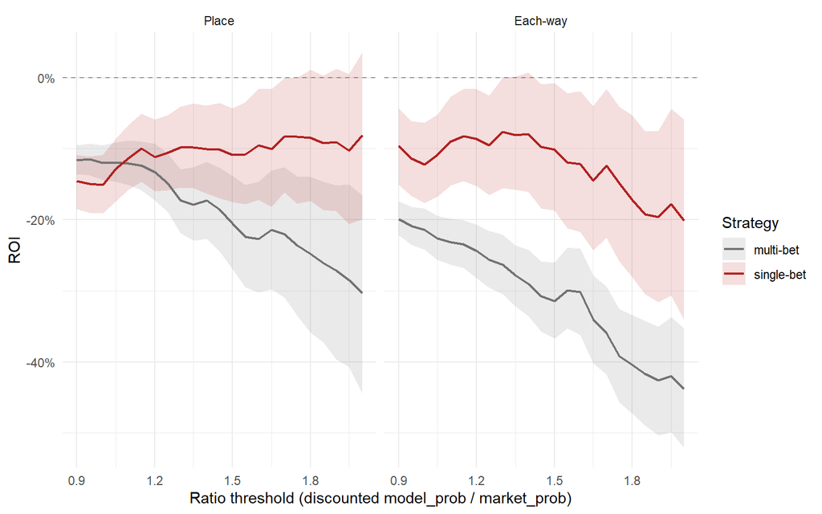

**Backing all qualifiers.** For continuity with papers 1 and 2a, the multi-bet rule — backing every qualifier — returns -17.3% on place and -26.3% on each-way, both worse than single-bet because the additional qualifiers are lower-conviction picks. Each-way is worse still. Backing every horse each-way at these terms loses -18.5% before any selection — the 1/5 place terms pay less than the fair place price in large fields — and the model’s weaker place selections, exposed twice (once in choosing which horses, once in the place leg’s payout), push multi-bet each-way below that floor.

# 5 Discussion

The exploded model predicts the top-3 finishing order with skill clearly above chance, yet on neither ranking metric does it match the market. That is the same pattern papers 1 and 2a found on the win objective — a model with genuine signal that the starting price nonetheless out-scores — now repeated on the ranking objective. The reading carries over unchanged: the market price aggregates information the pre-race feature set does not contain. On ranking accuracy (Q1), the market leads on both metrics — the ranking objective does not close that gap. On win prediction (Q2), the ranking-fitted model does better than paper 2a’s win-fitted model, the first improvement in the series that clears zero. Turned into bets, the model’s place and each-way strategies both lose.

The second question applies the ranking-fitted model to the win objective, and here the result is new to the series. Trained on the finishing order rather than on the winner alone, the model is a better winner-picker than paper 2a’s model: a paired race-level bootstrap puts the gain at +8.0 pp, with a 90% interval that lies above zero — the first distinguishable improvement across the three papers. The improvement comes from richer training data, not a different model. Depth-3 explosion gives roughly three times as many choice problems from the same races, producing sharper coefficient estimates for the same features. Wolverhampton is the clean illustration: its draw term was too noisy to retain when the model was fitted on wins alone ($p \approx 0.066$) but is estimated sharply under the ranking objective ($p =$ 0.0003), with the same sign and a similar magnitude. The reading is the narrow one — the ranking objective estimates the same draw effect paper 2a saw, sharply enough to retain it — not a new effect uncovered. Both models still lose money; the -17.4% is better than 2a’s -25.4%, but neither beats the market.

Paper 3 will change the model class. A tree-based learner accommodates non-linearities and feature interactions directly — among them a horse’s going affinity, which the conditional logit can express only through explicit interaction terms — without the modeller specifying each one in advance.

Turned into bets, a realistic one-bet-per-race strategy is materially better than backing every qualifier: place returns -9.8% and each-way -7.7%, against -17.3% and -26.3% for the multi-bet rule — the paper’s applied finding, and a place/each-way effect only (on the win market single-bet gives no advantage: -15.1% here, -25.9% for paper 2a). The losses are still dominated by the SP margin, not mis-selection: backing every runner at SP loses -22.8% and backing the favourite -6.6%[^2], so the model’s win selections sit between a zero-skill floor and a trivial heuristic. But single-bet place at -9.8% against a ~16% SP over-round is roughly half the structural drag, and against a lower-friction market such as a Betfair exchange (~5% commission) that margin is far smaller — a direction worth testing, left to a future paper.

# Acknowledgments

I have been interested in modelling horse racing since first acquiring the Smartform database more than a decade ago. The project has been picked up and put down many times, the obstacle almost always being the gap between an idea and a running implementation. What is different now is that working alongside Claude Code (Anthropic’s coding agent), with web-based Claude as a research companion, has compressed that gap dramatically. I am grateful to my brother, Michael Gillen, for the suggestion to build the model on All-Weather races — the foundation of the scope choices set out in Section 2. The design choices — dataset, scope, model, comparison, editorial line — are mine. The implementation, the bulk of the draft prose, and a great deal of the verification were Claude Code’s, under my direction; every output was reviewed and edited before it reached the paper. I do not yet know what general lessons this experiment points to about the value of human–AI collaboration in applied statistics. That uncertainty is part of why I am doing the work, and these papers are partly a record of that experiment.

# References

Harville, David A. 1973. “Assigning Probabilities to the Outcomes of Multi-Entry Competitions.” *Journal of the American Statistical Association* 68 (342): 312–16.

Henery, R. J. 1981. “Permutation Probabilities as Models for Horse Races.” *Journal of the Royal Statistical Society: Series B (Methodological)* 43 (1): 86–91.

Lo, Victor S. Y., and John Bacon-Shone. 1994. “A Comparison Between Two Models for Predicting Ordering Probabilities in Multiple-Entry Competitions.” *Journal of the Royal Statistical Society: Series D (The Statistician)* 43 (2): 317–27.

Lo, Victor S. Y., and John Bacon-Shone. 2008. “Approximating the Ordering Probabilities of Multi-Entry Competitions by a Simple Method.” In *Handbook of Sports and Lottery Markets*, edited by Donald B. Hausch and William T. Ziemba. North-Holland (Elsevier).

McFadden, Daniel. 1974. *Conditional Logit Analysis of Qualitative Choice Behavior*. (New York), 105–42.

Plackett, R. L. 1975. “The Analysis of Permutations.” *Journal of the Royal Statistical Society: Series C (Applied Statistics)* 24 (2): 193–202.

## 6 Appendix: Derivations

This appendix derives the Plackett–Luce model and its exploded-logit representation — the ranking machinery fitted in Section 3 — and the Harville place-probability formula behind the market’s ordering probabilities in Section 2. It builds on the conditional logit derived in paper 1’s appendix, whose notation we reuse: race $i$ is the chooser, horse $j$ the alternative, the linear predictor for horse $j$ in race $i$ is $z_{ij} = \sum_{l} \beta_l x_{ilj}$ over alternative-specific features $x_{ilj}$, and win probabilities are given by the softmax $p_{ij} = e^{z_{ij}} / \sum_m e^{z_{im}}$.

## 6.1 From conditional logit to Plackett–Luce

The conditional-logit model estimates only the probability that a particular horse *wins* a race. In practice, we observe a full or partial *ranking* of the field, which contains more information than the win alone. The Plackett–Luce model (Plackett 1975) extends conditional logit to rankings by treating the observed order of finishers as a sequence of conditional win probabilities: horse $j_1$ wins the race, then horse $j_2$ wins among the remainder, and so on.

Formally, let $j_1, j_2, \ldots, j_k$ denote the top $k$ finishers in race $i$, in order. The Plackett–Luce probability of this partial ranking is
$$P(j_1, j_2, \ldots, j_k)
= \prod_{s=1}^{k}
\frac{e^{z_{ij_s}}}{\sum_{r=s}^{J} e^{z_{ij_r}}},$$
where the denominator at step $s$ sums over all horses not yet ranked. Setting $k = J$ gives the probability of a full ranking; setting $k < J$ gives the truncated version, in which only the top $k$ finishers are modelled. In racing, truncation is natural: while the top few finishers are separated by genuine differences in ability and conditions on the day, the ordering among the tail of the field is largely noise and carries little useful signal (Henery 1981). Truncating at $k$ discards this noise; paper 2b takes $k = 3$.

The log-likelihood over a set of races is
$$\sum_{i=1}^n \sum_{s=1}^{k}
\left( z_{ij_s} - \log\sum_{r=s}^{J} e^{z_{ij_r}} \right).$$
As in the conditional-logit case, this is concave in the coefficients, so any local maximum is the global maximum.

### 6.1.1 Exploded conditional logit and Plackett–Luce equivalence

The Plackett–Luce likelihood has a natural interpretation in terms of conditional logit. Each factor in the product
$$\prod_{s=1}^{k}
\frac{e^{z_{ij_s}}}{\sum_{r=s}^{J} e^{z_{ij_r}}}$$
is precisely the conditional-logit probability that horse $j_s$ wins *among the horses remaining at position $s$*. So the Plackett–Luce likelihood is equivalent to the likelihood of $k$ separate conditional-logit problems, one for each position in the ranking, each defined on a shrinking choice set. This is known as the *exploded logit*: each race is exploded into $k$ conditional-logit observations.

Concretely, define $\mathcal{C}_{is} = \{j_s, j_{s+1}, \ldots, j_J\}$ as the choice set at position $s$ — the horses not yet ranked. Then the Plackett–Luce log-likelihood can be written as
$$\sum_{i=1}^n \sum_{s=1}^{k}
\left( z_{ij_s} - \log \sum_{j \in \mathcal{C}_{is}} e^{z_{ij}}\right),$$
which is identical in form to the conditional-logit log-likelihood (McFadden 1974), summed over $nk$ observations.

In practice, each race is exploded into $k$ fictitious races: the first is the real race with the full field; the second is a fictitious race consisting only of the horses that finished second or worse; the third a fictitious race consisting only of those that finished third or worse; and so on. These $nk$ races — real and fictitious — are pooled into a single dataset, and a single conditional-logit model is fit across the whole pool. By making fuller use of the finishing order rather than just the win, this yields more precise estimates of $\boldsymbol{\beta}$.

## 6.2 Harville order and place probabilities: the market comparison

The exploded logit above is the *model* side of Section 4; its *market* side needs place probabilities — the chance a horse finishes in the top $k$ — from win starting prices alone. Harville (Harville 1973) supplies them under a single assumption: once the winner is removed, the remaining horses re-race with win probabilities proportional to their original ones, so the field’s relative strengths are unchanged by the result.

**Order probability.** Let $p_1, \ldots, p_J$ be the win probabilities. Under the assumption, given that horse $i$ won, horse $j$’s conditional probability of winning the “race for second” is $p_j / (1 - p_i)$ — its share of the strength remaining once $i$ is removed. Iterating down the order, the probability of a full finishing sequence $(j_1, j_2, \ldots, j_J)$ is
$$P(j_1, j_2, \ldots, j_J)
= \prod_{s=1}^{J} \frac{p_{j_s}}{1 - \sum_{r < s} p_{j_r}},$$
each factor being the leader’s share of the strength not yet placed.

**Equivalence with Plackett–Luce.** This is exactly the Plackett–Luce order probability derived above. Writing $p_j = e^{z_j} / \sum_m e^{z_m}$, the denominator $1 - \sum_{r<s} p_{j_r}$ equals $\big(\sum_{r \ge s} e^{z_{j_r}}\big) / \sum_m e^{z_m}$; the normaliser $\sum_m e^{z_m}$ cancels against the one in the numerator’s $p_{j_s}$, leaving $\prod_s e^{z_{j_s}} / \sum_{r \ge s} e^{z_{j_r}}$ — the Plackett–Luce expression. Undiscounted Harville and Plackett–Luce are the same model, reached from different starting points (sequential conditioning on win probabilities versus a ranking likelihood). This is why an undiscounted Harville comparison cannot judge a Plackett–Luce-fitted model: it *is* that model’s formula, evaluated at the market’s win probabilities rather than the model’s.

**Place probability.** The marginal probability that a given horse finishes in the top $k$ is the sum of the order probability over every sequence that places it among the first $k$. Harville’s product form keeps this tractable: for $k = 3$ the top-3 marginal for horse $j$ is
$$P(j \in \text{top 3})
= p_j
+ \sum_{i \ne j} p_i\, \frac{p_j}{1 - p_i}
+ \sum_{i \ne j} \sum_{m \ne i, j}
p_i\, \frac{p_m}{1 - p_i}\, \frac{p_j}{1 - p_i - p_m},$$
the three terms being the probabilities that $j$ finishes first, second and third. The inner sums have only $O(J)$ and $O(J^2)$ terms, so the place probabilities are computed in closed form without enumerating the $J!$ orders.

**Discounted Harville.** Pure Harville is known to overstate favourites’ place chances and understate longshots’ — the favourite–longshot bias in the place dimension — because the sequential-conditional assumption hands too much of the remaining probability mass to the strongest horse at each step. Lo & Bacon-Shone (Lo and Bacon-Shone 1994, 2008) correct it by replacing $p_i$ with $p_i^{\alpha}$ ($\alpha < 1$, and smaller at deeper positions) inside the conditional steps before renormalising — $\alpha = 0.80$ for second place and $0.65$ for third in this paper. Because each conditional is then built from the discounted strengths $p_i^{\alpha}$ rather than the win probabilities themselves, the cancellation that produced the Plackett–Luce form no longer happens: the discounted order probability is not a product of plain win probabilities, and the discounted Harville and Plackett–Luce models cease to coincide. That break is what makes the discounted comparison a genuine yardstick for the exploded model rather than a re-expression of it.

The mixed discrete-choice derivation, used in paper 2a for race-level interactions, is given in paper 2a’s appendix.

## 7 Appendix: Software and reproducibility

The software stack — R, the tidyverse, {mlogit} for the conditional-logit and exploded fits, {DBI}/{RMariaDB} for the Smartform database, {renv} for package pinning, and Quarto for typesetting — is the same as paper 1’s, whose appendix B describes it in full, and we do not repeat that here. As there, the whole analysis is a {targets} pipeline: each step in the data → features → model → render chain is a `tar_target()`, intermediate results are cached on disk, and a single `targets::tar_make()` from the project root rebuilds every stale step and re-renders the paper. Fitting is on the training split only; every out-of-sample figure is computed on the held-out test races.

## Footnotes

[^1]: Q1 scores 2,183 races and Q2 below scores 2,193; the difference is that the ranking metrics require a clean, unambiguous top-3 (positions 1–3 each recorded exactly once) and a complete market win-probability vector, a filter the depth-1 win backtest in Q2 does not need.
[^2]: Ties for favourite — the lowest decimal starting price shared by two or more runners — occur in 9.1% of test races and are broken here by taking the lower-numbered runner.